# Analysis of Experiment 1

In Experiment 1, participants searched for a green ellipse target and indicated its orientation - either clockwise or counter-clockwise. The target’s shape and color remained consistent throughout all trials, while the distractors varied shape and color, independent of the response feature of the target. According to the distractor-response binding (DRB), we would expect an interaction between the distractor feature and the response, which would closely resemble an intertrial priming effect.

After loading the data, we examin the effects using ANOVA.

```r
ies_dat_probe %>% ezANOVA(dv=ies, wid=participant, within=.(shape_rep, col_rep, pos_fixed, resp_rep)) -> anova_ies
kable(anova_ies$ANOVA)
```

|  | Effect | DFn | DFd | F | p | p<.05 | ges |
| --- | --- | --- | --- | --- | --- | --- | --- |
| 2 | shape_rep | 1 | 23 | 2.695 | 0.114 |  | 0.000 |
| 3 | col_rep | 1 | 23 | 3.637 | 0.069 |  | 0.000 |
| 4 | pos_fixed | 1 | 23 | 28.548 | 0.000 | * | 0.063 |
| 5 | resp_rep | 1 | 23 | 23.311 | 0.000 | * | 0.024 |
| 6 | shape_rep:col_rep | 1 | 23 | 0.009 | 0.927 |  | 0.000 |
| 7 | shape_rep:pos_fixed | 1 | 23 | 0.025 | 0.875 |  | 0.000 |
| 8 | col_rep:pos_fixed | 1 | 23 | 1.880 | 0.184 |  | 0.000 |
| 9 | shape_rep:resp_rep | 1 | 23 | 16.464 | 0.000 | * | 0.002 |
| 10 | col_rep:resp_rep | 1 | 23 | 0.010 | 0.922 |  | 0.000 |
| 11 | pos_fixed:resp_rep | 1 | 23 | 8.990 | 0.006 | * | 0.003 |
| 12 | shape_rep:col_rep:pos_fixed | 1 | 23 | 0.424 | 0.521 |  | 0.000 |
| 13 | shape_rep:col_rep:resp_rep | 1 | 23 | 1.058 | 0.314 |  | 0.000 |
| 14 | shape_rep:pos_fixed:resp_rep | 1 | 23 | 0.847 | 0.367 |  | 0.000 |
| 15 | col_rep:pos_fixed:resp_rep | 1 | 23 | 0.117 | 0.736 |  | 0.000 |
| 16 | shape_rep:col_rep:pos_fixed:resp_rep | 1 | 23 | 0.139 | 0.713 |  | 0.000 |

```r
ies_dat_probe %>% ezStats(dv=ies, wid=participant, within=.(resp_rep))
```

| resp_rep | N | Mean | SD | FLSD |
| --- | --- | --- | --- | --- |
| Change | 24 | 798 | 148 | 21.9 |
| Repeat | 24 | 747 | 169 | 21.9 |

```r
ies_dat_probe %>% ezStats(dv=ies, wid=participant, within=.(pos_fixed))
```

| pos_fixed | N | Mean | SD | FLSD |
| --- | --- | --- | --- | --- |
| Random | 24 | 815 | 187 | 33 |
| Fixed | 24 | 730 | 130 | 33 |

As we can see, the main effects of position, response repetition are significant. In addition, the interaction between shape repetition and response repetition is significant, as well as the response repetition and position interaction.

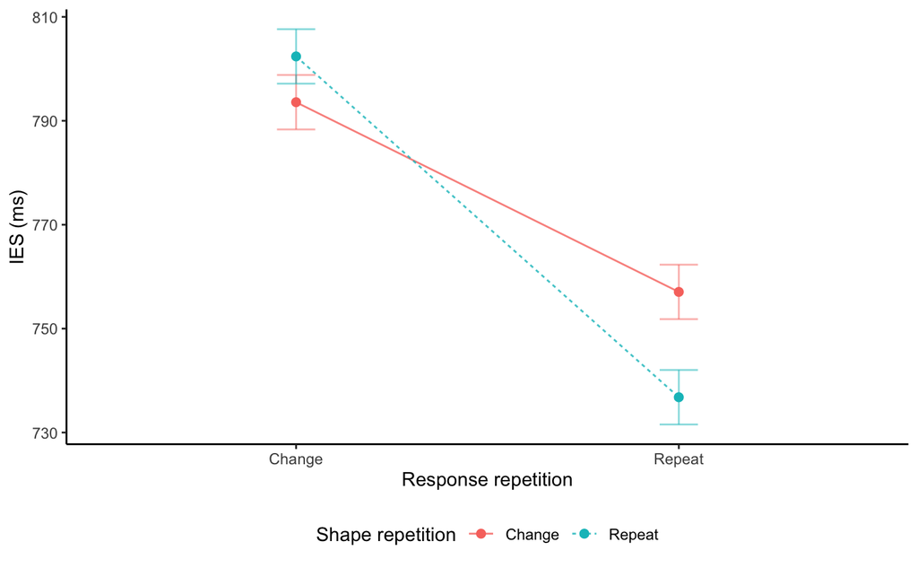

```r
ies_dat_probe %>% ezPlot(dv=ies, wid=participant, x= resp_rep, split = shape_rep, within=.(resp_rep, shape_rep),
                         bar_width = 0.1) + theme_classic() + geom_point(size=2, aes(color = shape_rep)) +
  theme(legend.position = 'bottom') +
    labs(x = "Response repetition", y = "IES (ms)", color = "Shape repetition", linetype = "Shape repetition", shape = "Shape repetition") -> fig_interaction1
fig_interaction1
```

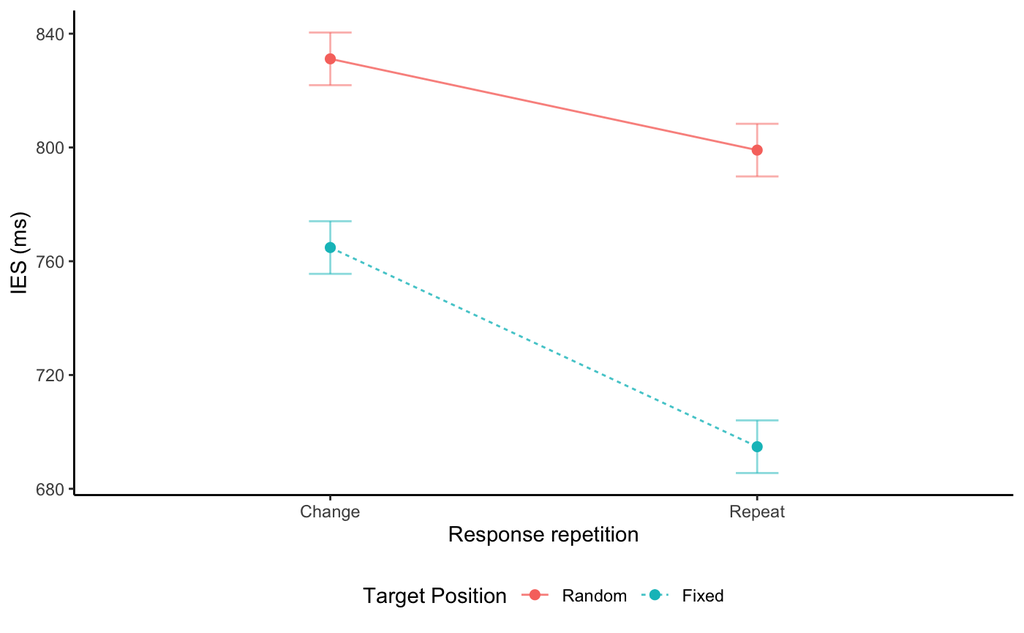

```r
ies_dat_probe %>% ezPlot(dv=ies, wid=participant, x= resp_rep, split = pos_fixed, within=.(resp_rep, pos_fixed),
                         bar_width = 0.1) + theme_classic()  + geom_point(size=2, aes(color = pos_fixed)) +
  theme(legend.position = 'bottom') +
    labs(x = "Response repetition", y = "IES (ms)", color = "Target Position", linetype = "Target Position", shape = "Target Position") -> fig_interaction2
fig_interaction2
```

Combine two interaction plots into one figure.

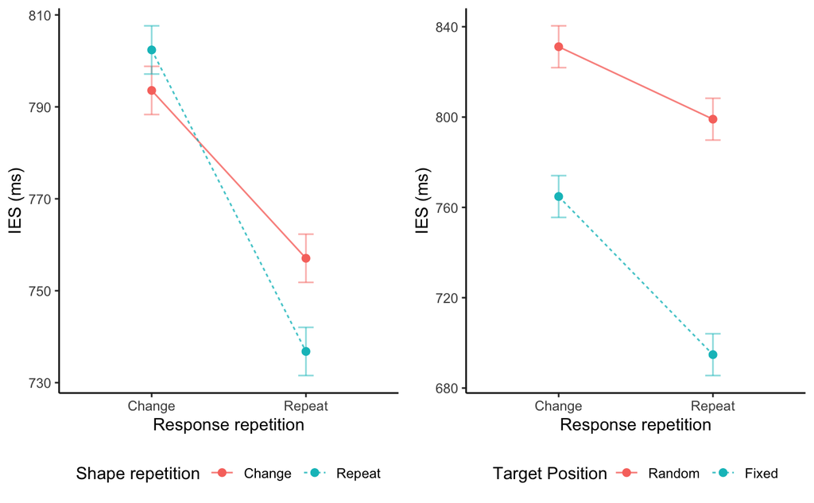

```r
plot_grid(fig_interaction1, fig_interaction2, ncol=2) -> fig_interaction
#save the plot
ggsave("figures/interaction_plot_ies.png", fig_interaction, width=8, height=4)
fig_interaction
```